Скуп података под називом „ Used cars catalog“, који ћемо представити у семинарском раду, представља колекцију података о половним аутомобилима узетих са више интернет сајтова у Белорусији у децембру 2019. године.

База података

База података се састоји од једног .csv фајла

Учитаћемо библиотеке неопходне за даљи рад.

```r
library(tidyverse)
library(ISLR)
library(visdat)
library(car)
library(leaps)
```

Учитавање скупа података из .csv фајла.

```r
carsDataSet = read.csv("cars.csv", stringsAsFactors = F)
```

Пре даљег рада издвојићемо само колоне које су нам потребне, док ћемо колоне које нам представљају проблем, због превише нејасноћа, отклонити из скупа.

```r
carSubset = subset(carsDataSet,select= c("manufacturer_name","transmission","color","odometer_value","year_produced","engine_fuel","engine_has_gas","engine_type",
                                         "engine_capacity","body_type","has_warranty","state","drivetrain","price_usd","is_exchangeable","number_of_photos","duration_listed"))
```

Погледаћемо детаљније скуп података који ћемо обрађивати.  
Описаћемо само променљиве које ћемо користити у даљој анализи скупа carSubset.  
manufacturer_name: Произвођач аутомобила (Категоријска променљива)  
transmission: Тип мењача аутомобила (Категоријска променљива)  
color: Боја аутомобила (Категоријска променљива)  
odometer_value: Пређена километража (Нумеричка променљива)  
year_produced: Година производње (Нумеричка променљива)  
engine_fuel: Тип горива мотора (Категоријска променљива)  
engine_has_gas: Да ли аутомобил има уграђен гас (Логичка променљива)  
engine_type: Тип мотора (Категоријска променљива)  
engine_capacity: Запремина мотора (Нумеричка променљива)  
body_type: Тип каросерије (Категоријска променљива)  
has_warranty: Да ли возило има гаранцију (Логичка променљива)  
state: Стање возила. Описује да ли је возило ново, половно или оштећено (Категоријска променљива)  
drivetrain: Тип погона возила - Предњи, задњи или сва четири точка. (Категоријска променљива)  
is_exchangeable: Да ли је могућа замена (Логичка променљива)  
number_of_photos: Број фотографија возила на огласу. (Нумеричка променљива)  
duration_listed: Број дана колико је оглас приказан на сајту (Нумеричка променљива)

Циљна променљива: price_usd: Цена возила у америчким доларима. (Нумеричка променљива)

```r
str(carSubset)
```

```
## 'data.frame':    38531 obs. of  17 variables:
##  $ manufacturer_name: chr  "Subaru" "Subaru" "Subaru" "Subaru" ...
##  $ transmission     : chr  "automatic" "automatic" "automatic" "mechanical" ...
##  $ color            : chr  "silver" "blue" "red" "blue" ...
##  $ odometer_value   : int  190000 290000 402000 10000 280000 132449 318280 350000 179000 571317 ...
##  $ year_produced    : int  2010 2002 2001 1999 2001 2011 1998 2004 2010 1999 ...
##  $ engine_fuel      : chr  "gasoline" "gasoline" "gasoline" "gasoline" ...
##  $ engine_has_gas   : logi  FALSE FALSE FALSE FALSE FALSE FALSE ...
##  $ engine_type      : chr  "gasoline" "gasoline" "gasoline" "gasoline" ...
##  $ engine_capacity  : num  2.5 3 2.5 3 2.5 2.5 2.5 2.5 2.5 2.5 ...
##  $ body_type        : chr  "universal" "universal" "suv" "sedan" ...
##  $ has_warranty     : logi  FALSE FALSE FALSE FALSE FALSE FALSE ...
##  $ state            : chr  "owned" "owned" "owned" "owned" ...
##  $ drivetrain       : chr  "all" "all" "all" "all" ...
##  $ price_usd        : num  10900 5000 2800 9999 2134 ...
##  $ is_exchangeable  : logi  FALSE TRUE TRUE TRUE TRUE TRUE ...
##  $ number_of_photos : int  9 12 4 9 14 20 8 7 17 8 ...
##  $ duration_listed  : int  16 83 151 86 7 67 307 73 87 43 ...
```

На основу приказа структуре скупа података, можемо закључити да имамо три различита типа података, нумеричке, логичке и карактер променљиве.

```r
summary(carSubset)
```

```
##  manufacturer_name  transmission          color           odometer_value
##  Length:38531       Length:38531       Length:38531       Min.   :      0
##  Class :character   Class :character   Class :character   1st Qu.: 158000
##  Mode  :character   Mode  :character   Mode  :character   Median : 250000
##                                                           Mean   : 248865
##                                                           3rd Qu.: 325000
##                                                           Max.   :1000000
##
##  year_produced  engine_fuel        engine_has_gas  engine_type
##  Min.   :1942   Length:38531       Mode :logical   Length:38531
##  1st Qu.:1998   Class :character   FALSE:37184     Class :character
##  Median :2003   Mode  :character   TRUE :1347      Mode  :character
##  Mean   :2003
##  3rd Qu.:2009
##  Max.   :2019
##
##  engine_capacity  body_type         has_warranty       state
##  Min.   :0.200   Length:38531       Mode :logical   Length:38531
##  1st Qu.:1.600   Class :character   FALSE:38082     Class :character
##  Median :2.000   Mode  :character   TRUE :449       Mode  :character
##  Mean   :2.055
##  3rd Qu.:2.300
##  Max.   :8.000
##  NA's   :10
##   drivetrain          price_usd     is_exchangeable number_of_photos
##  Length:38531       Min.   :    1   Mode :logical   Min.   : 1.000
##  Class :character   1st Qu.: 2100   FALSE:24945     1st Qu.: 5.000
##  Mode  :character   Median : 4800   TRUE :13586     Median : 8.000
##                     Mean   : 6640                   Mean   : 9.649
##                     3rd Qu.: 8990                   3rd Qu.:12.000
##                     Max.   :50000                   Max.   :86.000
##
##  duration_listed
##  Min.   :   0.00
##  1st Qu.:  23.00
##  Median :  59.00
##  Mean   :  80.58
##  3rd Qu.:  91.00
##  Max.   :2232.00
##
```

Извршавањем функције summary добијамо детаљније информације о нашем скупу, као што су минимум и максмум, медијана, средња вредност као и да ли скуп садржи недостајуће вредности. У нашем случају NA вредности налазе се само у колони о кубикажи мотора. Детаљнијом провером колона, закључили смо да код стринг вредности немамо недостајуће вредности попут празног стринга, цртице или томе слично.

```r
carSubset$model_name[carSubset$model_name == ""]
```

```r
carSubset$model_name[carSubset$model_name == "-"]
```

Поступак је поновљен за све колоне карактер типа.

Недостајуће вредности

```r
carSubset$year_produced[carSubset$year_produced  < 1970 ] <- NA
```

Због мањег интересовања купаца за возила старија од 50 година, одлучили смо да уместо тих возила поставимо недостајуће вредности. Сва возила произведена пре 1970. године добиће Na вредност.

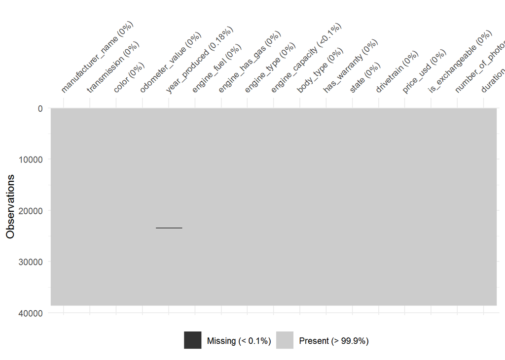

```r
vis_miss(carSubset)
```

На графичком приказу недостајућих вредности скупа података, можемо видети да је тај број веома мали чак мањи од 0.1%.

Обрада недостајућих вредности

```r
summary(carSubset)
```

```
##  manufacturer_name  transmission          color           odometer_value
##  Length:38531       Length:38531       Length:38531       Min.   :      0
##  Class :character   Class :character   Class :character   1st Qu.: 158000
##  Mode  :character   Mode  :character   Mode  :character   Median : 250000
##                                                           Mean   : 248865
##                                                           3rd Qu.: 325000
##                                                           Max.   :1000000
##
##  year_produced  engine_fuel        engine_has_gas  engine_type
##  Min.   :1970   Length:38531       Mode :logical   Length:38531
##  1st Qu.:1998   Class :character   FALSE:37184     Class :character
##  Median :2003   Mode  :character   TRUE :1347      Mode  :character
##  Mean   :2003
##  3rd Qu.:2009
##  Max.   :2019
##  NA's   :71
##  engine_capacity  body_type         has_warranty       state
##  Min.   :0.200   Length:38531       Mode :logical   Length:38531
##  1st Qu.:1.600   Class :character   FALSE:38082     Class :character
##  Median :2.000   Mode  :character   TRUE :449       Mode  :character
##  Mean   :2.055
##  3rd Qu.:2.300
##  Max.   :8.000
##  NA's   :10
##   drivetrain          price_usd     is_exchangeable number_of_photos
##  Length:38531       Min.   :    1   Mode :logical   Min.   : 1.000
##  Class :character   1st Qu.: 2100   FALSE:24945     1st Qu.: 5.000
##  Mode  :character   Median : 4800   TRUE :13586     Median : 8.000
##                     Mean   : 6640                   Mean   : 9.649
##                     3rd Qu.: 8990                   3rd Qu.:12.000
##                     Max.   :50000                   Max.   :86.000
##
##  duration_listed
##  Min.   :   0.00
##  1st Qu.:  23.00
##  Median :  59.00
##  Mean   :  80.58
##  3rd Qu.:  91.00
##  Max.   :2232.00
##
```

С обзиром да имамо NA вредности у колони engine_capacitу, а како је она континуална променљива те вредности попунићемо медијаном те колоне.

```r
med = median(carSubset$engine_capacity, na.rm=TRUE)
print(med)
```

```
## [1] 2
```

```r
carSubset %>% group_by(engine_capacity) %>% count(engine_capacity, sort= TRUE)
```

```
## # A tibble: 62 x 2
## # Groups:   engine_capacity [62]
##    engine_capacity     n
##              <dbl> <int>
##  1             2    7670
##  2             1.6  6188
##  3             1.8  4244
##  4             2.5  2520
##  5             1.4  2394
##  6             1.9  2304
##  7             2.2  1852
##  8             2.4  1596
##  9             3    1520
## 10             1.5  1461
## # ... with 52 more rows
```

Из приложеног видимо да је медијана 2.0, али и да је та вредност најзаступљенија у колони и том вредношћу попуњавамо NA вредности.

```r
carSubset$engine_capacity[is.na(carSubset$engine_capacity)] <- med
```

```r
summary(carSubset)
```

```
##  manufacturer_name  transmission          color           odometer_value
##  Length:38531       Length:38531       Length:38531       Min.   :      0
##  Class :character   Class :character   Class :character   1st Qu.: 158000
##  Mode  :character   Mode  :character   Mode  :character   Median : 250000
##                                                           Mean   : 248865
##                                                           3rd Qu.: 325000
##                                                           Max.   :1000000
##
##  year_produced  engine_fuel        engine_has_gas  engine_type
##  Min.   :1970   Length:38531       Mode :logical   Length:38531
##  1st Qu.:1998   Class :character   FALSE:37184     Class :character
##  Median :2003   Mode  :character   TRUE :1347      Mode  :character
##  Mean   :2003
##  3rd Qu.:2009
##  Max.   :2019
##  NA's   :71
##  engine_capacity  body_type         has_warranty       state
##  Min.   :0.200   Length:38531       Mode :logical   Length:38531
##  1st Qu.:1.600   Class :character   FALSE:38082     Class :character
##  Median :2.000   Mode  :character   TRUE :449       Mode  :character
##  Mean   :2.055
##  3rd Qu.:2.300
##  Max.   :8.000
##
##   drivetrain          price_usd     is_exchangeable number_of_photos
##  Length:38531       Min.   :    1   Mode :logical   Min.   : 1.000
##  Class :character   1st Qu.: 2100   FALSE:24945     1st Qu.: 5.000
##  Mode  :character   Median : 4800   TRUE :13586     Median : 8.000
##                     Mean   : 6640                   Mean   : 9.649
##                     3rd Qu.: 8990                   3rd Qu.:12.000
##                     Max.   :50000                   Max.   :86.000
##
##  duration_listed
##  Min.   :   0.00
##  1st Qu.:  23.00
##  Median :  59.00
##  Mean   :  80.58
##  3rd Qu.:  91.00
##  Max.   :2232.00
##
```

Из приложеног видимо да у колони engine_capacity више немамо недостајућих вредности.

Како нам не би представљале проблем у даљем раду, обрисаћемо врсте са недостајућим вредностима у колони year_produced.

```r
carSubset <- na.omit(carSubset)
```

Визуелизација и анализа података

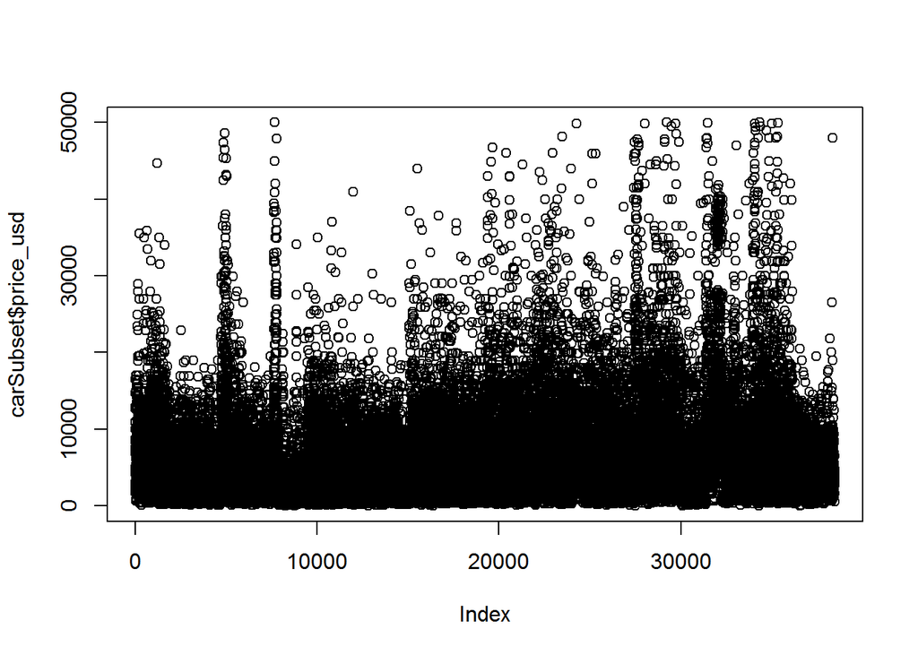

```r
plot(carSubset$price_usd)
```

Са графика видимо да цене у великој мери варирају, зато ћемо додати нову категоријску променљиву чије су категорије формиране на основу висине цене. Категорије су формиране на основу података прикупљених са сајта “Половни аутомобили”.

```r
extraLowPrice <- carSubset$price_usd[carSubset$price_usd <= 1000]
lowPrice <- carSubset$price_usd[carSubset$price_usd > 1000 & carSubset$price_usd <= 4000 ]
medPrice <- carSubset$price_usd[carSubset$price_usd > 4000 & carSubset$price_usd <= 10000]
highPrice <- carSubset$price_usd[carSubset$price_usd > 10000 & carSubset$price_usd <= 30000]
extraPrice <- carSubset$price_usd[carSubset$price_usd > 30000]

carSubset$price_cat <- vector(mode = "character", length = nrow(carSubset))
carSubset$price_cat[carSubset$price_usd %in% extraLowPrice ] <- "extraLowPrice"
carSubset$price_cat[carSubset$price_usd %in% lowPrice ] <- "lowPrice"
carSubset$price_cat[carSubset$price_usd %in% medPrice ] <- "medPrice"
carSubset$price_cat[carSubset$price_usd %in% highPrice ] <- "highPrice"
carSubset$price_cat[carSubset$price_usd %in% extraPrice ] <- "extraPrice"
```

На исти начин ћемо приступити променљивој која представља годину производње. Категорије су одређене према стандардима Европске Уније.

```r
veryOldCar <- carSubset$year_produced[carSubset$year_produced <= 1980]
oldCar <- carSubset$year_produced[carSubset$year_produced > 1980 & carSubset$year_produced <= 2000 ]
medAgeCar <- carSubset$year_produced[carSubset$year_produced > 2000 & carSubset$year_produced <= 2012]
newCar <- carSubset$year_produced[carSubset$year_produced > 2012]


carSubset$year_produced_cat <- vector(mode = "character", length = nrow(carSubset))
carSubset$year_produced_cat[carSubset$year_produced %in% veryOldCar ] <- "veryOldCar"
carSubset$year_produced_cat[carSubset$year_produced %in% oldCar ] <- "oldCar"
carSubset$year_produced_cat[carSubset$year_produced %in% medAgeCar ] <- "medAgeCar"
carSubset$year_produced_cat[carSubset$year_produced %in% newCar ] <- "newCar"
```

Ради лакше и тачније обраде податаке стринг варијабле ћемо факторизовати.

```r
carSubset = as.data.frame(unclass(carSubset),stringsAsFactors=TRUE)
```

```r
str(carSubset)
```

```
## 'data.frame':    38460 obs. of  19 variables:
##  $ manufacturer_name: Factor w/ 55 levels "Acura","Alfa Romeo",..: 51 51 51 51 51 51 51 51 51 51 ...
##  $ transmission     : Factor w/ 2 levels "automatic","mechanical": 1 1 1 2 1 1 1 1 1 1 ...
##  $ color            : Factor w/ 12 levels "black","blue",..: 9 2 8 2 1 9 1 9 5 9 ...
##  $ odometer_value   : int  190000 290000 402000 10000 280000 132449 318280 350000 179000 571317 ...
##  $ year_produced    : int  2010 2002 2001 1999 2001 2011 1998 2004 2010 1999 ...
##  $ engine_fuel      : Factor w/ 6 levels "diesel","electric",..: 4 4 4 4 4 4 4 4 4 4 ...
##  $ engine_has_gas   : logi  FALSE FALSE FALSE FALSE FALSE FALSE ...
##  $ engine_type      : Factor w/ 3 levels "diesel","electric",..: 3 3 3 3 3 3 3 3 3 3 ...
##  $ engine_capacity  : num  2.5 3 2.5 3 2.5 2.5 2.5 2.5 2.5 2.5 ...
##  $ body_type        : Factor w/ 12 levels "cabriolet","coupe",..: 11 11 10 9 11 11 11 9 11 11 ...
##  $ has_warranty     : logi  FALSE FALSE FALSE FALSE FALSE FALSE ...
##  $ state            : Factor w/ 3 levels "emergency","new",..: 3 3 3 3 3 3 3 3 3 3 ...
##  $ drivetrain       : Factor w/ 3 levels "all","front",..: 1 1 1 1 1 1 1 1 1 1 ...
##  $ price_usd        : num  10900 5000 2800 9999 2134 ...
##  $ is_exchangeable  : logi  FALSE TRUE TRUE TRUE TRUE TRUE ...
##  $ number_of_photos : int  9 12 4 9 14 20 8 7 17 8 ...
##  $ duration_listed  : int  16 83 151 86 7 67 307 73 87 43 ...
##  $ price_cat        : Factor w/ 5 levels "extraLowPrice",..: 3 5 4 5 4 3 4 5 3 5 ...
##  $ year_produced_cat: Factor w/ 4 levels "medAgeCar","newCar",..: 1 1 1 3 1 1 3 1 1 3 ...
```

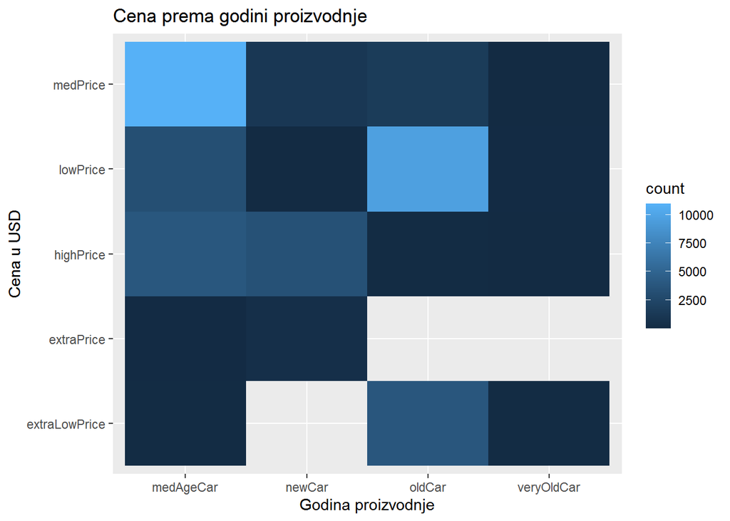

```r
ggplot(data =carSubset) + geom_bin2d( mapping = aes(x = year_produced_cat, y = price_cat)) + labs(title ="Cena prema godini proizvodnje", x="Godina proizvodnje", y="Cena u USD")
```

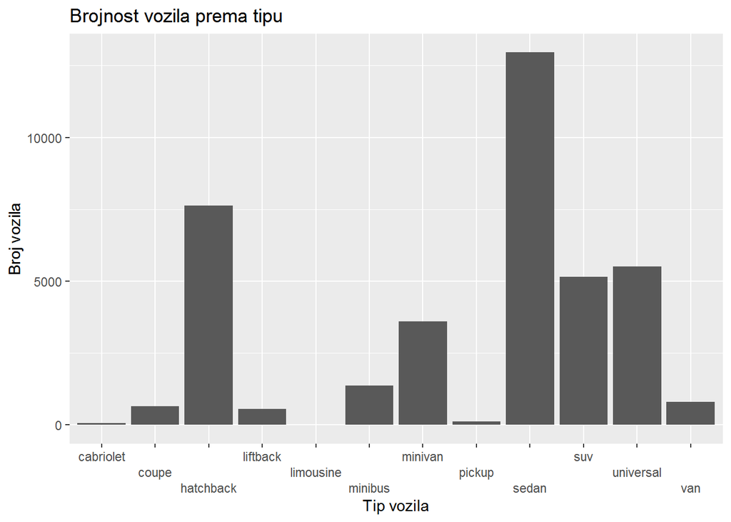

```r
ggplot(data= carSubset) + geom_bar(mapping=aes(x=body_type))+scale_x_discrete(guide = guide_axis(n.dodge=3))+ labs(title ="Brojnost vozila prema tipu", x="Tip vozila", y="Broj vozila")
```

Пошто се на фрафику не види категорија лимузине, додаћемо табеларни приказ који ће приказати бројност свих категорија.

```r
table(carSubset$body_type)
```

```
##
## cabriolet     coupe hatchback  liftback limousine   minibus   minivan    pickup
##        73       650      7638       552        12      1369      3608       127
##     sedan       suv universal       van
##     12963      5154      5506       808
```

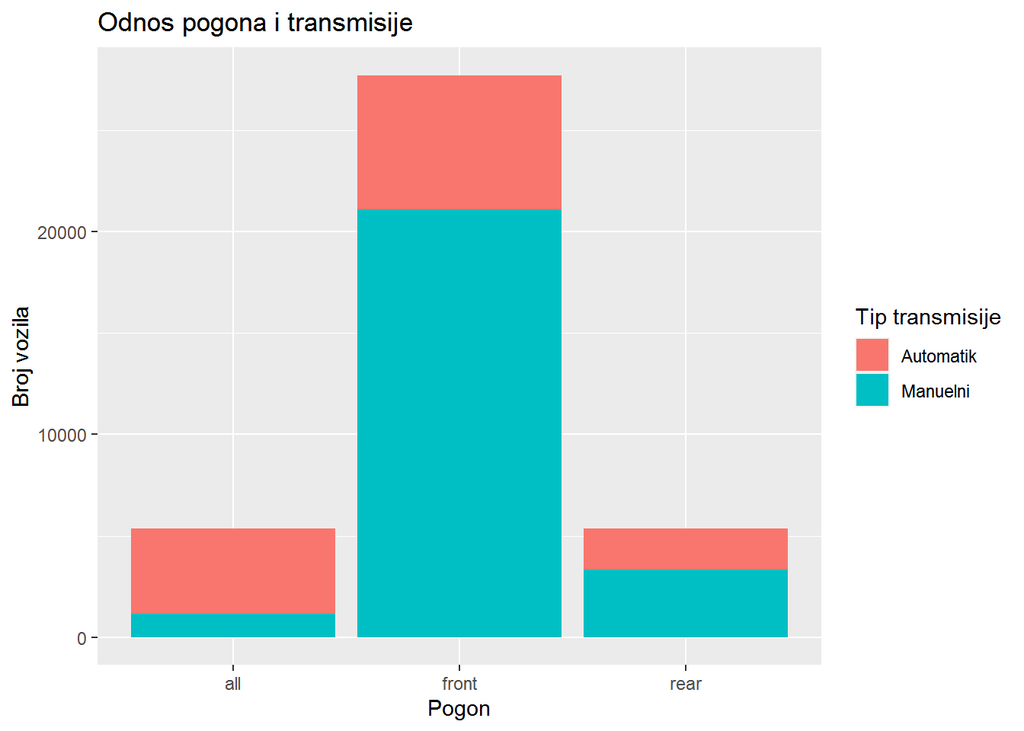

```r
ggplot(data=carSubset) + geom_bar(mapping=aes(x = drivetrain, fill = transmission)) + labs(title ="Odnos pogona i transmisije", x="Pogon", y="Broj vozila") + scale_fill_discrete(name="Tip transmisije", labels=c("Automatik", "Manuelni"))
```

Примећујемо да код погона на сва четири точка имамо већу заступљеност аутоматске трансмисије, док код остала два типа преовлађује мануелни.

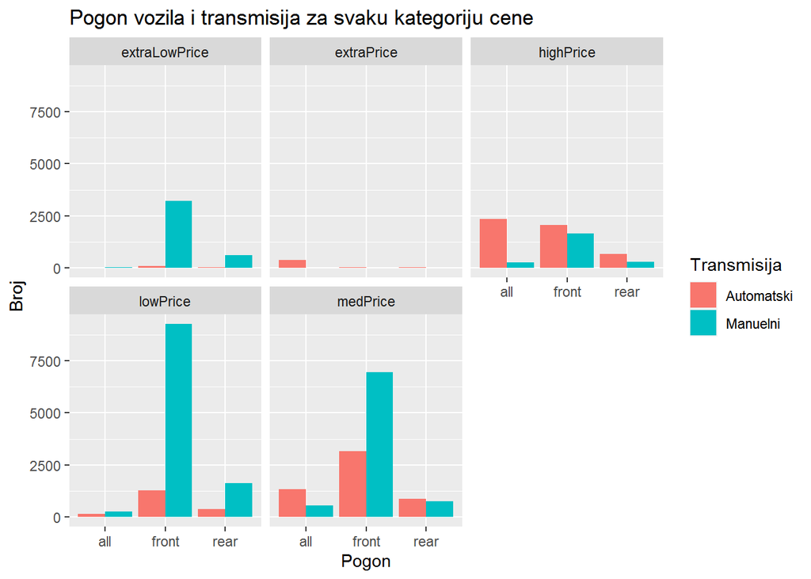

```r
ggplot(carSubset) +
  geom_bar(aes(x=drivetrain, fill=transmission),
           position = "dodge") +
  facet_wrap(~price_cat) + labs(x = "Pogon", y="Broj", title="Pogon vozila i transmisija za svaku kategoriju cene") +scale_fill_discrete(name="Transmisija", labels=c("Automatski", "Manuelni"))
```

Видимо да су код возила са вишим ценама у свакој категорији погона заступљенији аутоматски мењачи, док су код возила са нижим ценама у свакој категорији погона заступљенији мануелни мењачи. Код категорије medPrice трансмисија у већој мери зависи од погона. Такође видимо да међу возилима са нижим ценама доминирају она на предњи погон.

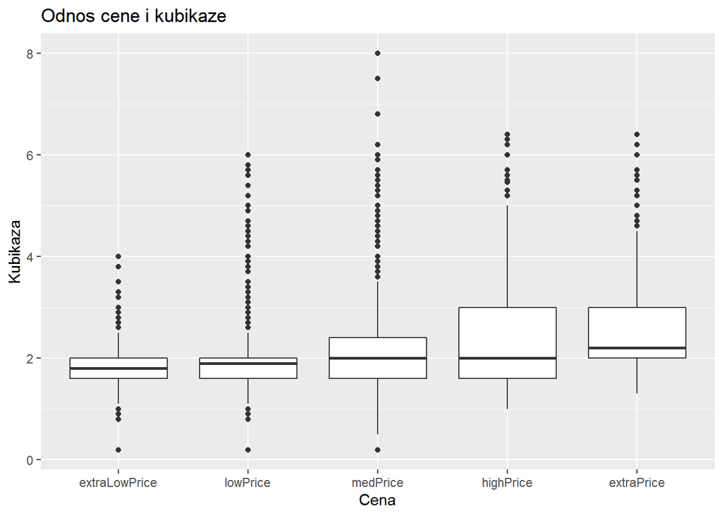

```r
ggplot(data=carSubset) + geom_boxplot(mapping=aes(x = reorder(price_cat,engine_capacity), y = engine_capacity))+labs(title ="Odnos cene i kubikaze", x="Cena", y="Kubikaza")
```

[figure not shown]

```r
ggplot(data =carSubset) + geom_boxplot(mapping=aes(x=reorder(price_cat,odometer_value), y=odometer_value)) +labs(title ="Cena vozila u odnosu na predjenu kilometrazu", x="Predjenih kilometara", y="Cena u USD")
```

Видимо да је цена возила нижа са порастом пређених километара, што је и очекивано. Одступања која видимо на претходним графицима, могу бити последица зависности цене од променљивих попут стања возила, марке возила, поседовања гаранције… У даљем истраживању покушаћемо да испитамо ту зависност.

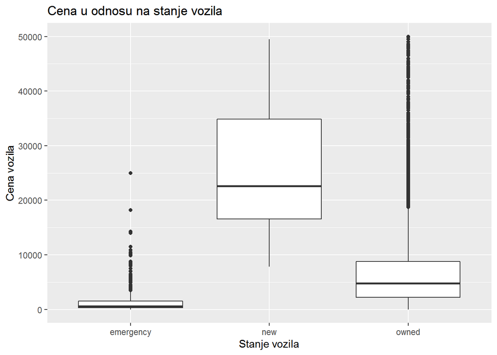

```r
ggplot(data=carSubset) + geom_boxplot(aes(x= state, y=price_usd)) + labs(title ="Cena u odnosu na stanje vozila",x="Stanje vozila", y= "Cena vozila")
```

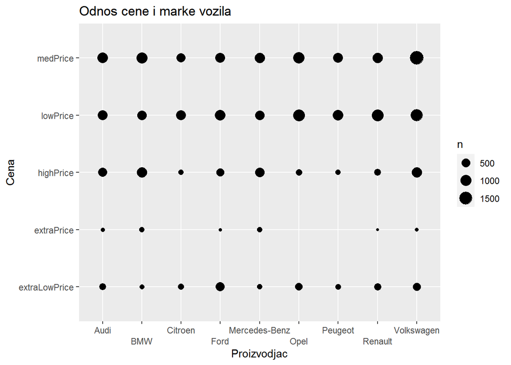

```r
plotCar <-carSubset %>% group_by(manufacturer_name) %>% filter(n() > 1400)

ggplot(data = plotCar) +
  geom_count(mapping = aes(x = manufacturer_name, y = price_cat)) + labs(x ="Proizvodjac", y="Cena", title="Odnos cene i marke vozila ") +   scale_x_discrete(guide = guide_axis(n.dodge=2))
```

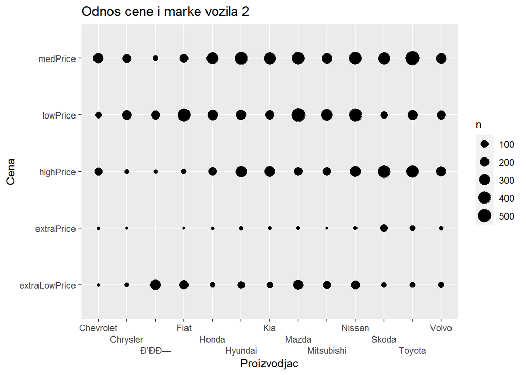

```r
plotCar2 <-carSubset %>% group_by(manufacturer_name) %>% filter( between(n(),400,1400))
ggplot(data = plotCar2) +
  geom_count(mapping = aes(x = manufacturer_name, y = price_cat)) + labs(x ="Proizvodjac", y="Cena", title="Odnos cene i marke vozila 2") +   scale_x_discrete(guide = guide_axis(n.dodge=3))
```

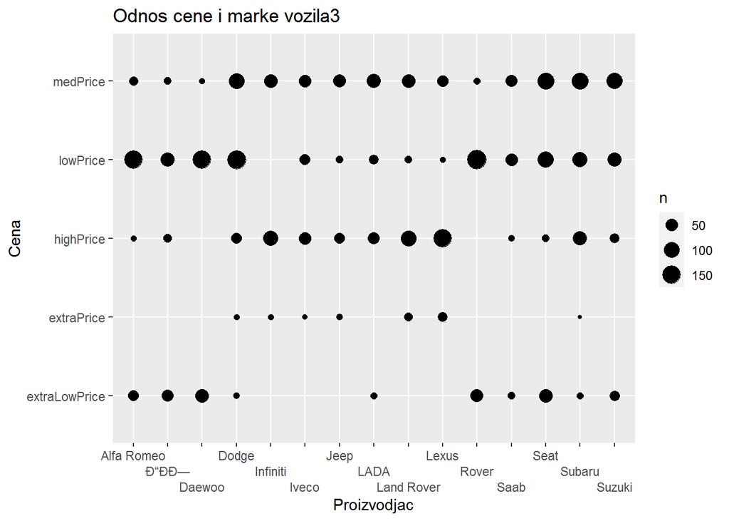

```r
plotCar3 <-carSubset %>% group_by(manufacturer_name) %>% filter( between(n(),100,400))
ggplot(data = plotCar3) +
  geom_count(mapping = aes(x = manufacturer_name, y = price_cat)) + labs(x ="Proizvodjac", y="Cena", title="Odnos cene i marke vozila3 ") +   scale_x_discrete(guide = guide_axis(n.dodge=3))
```

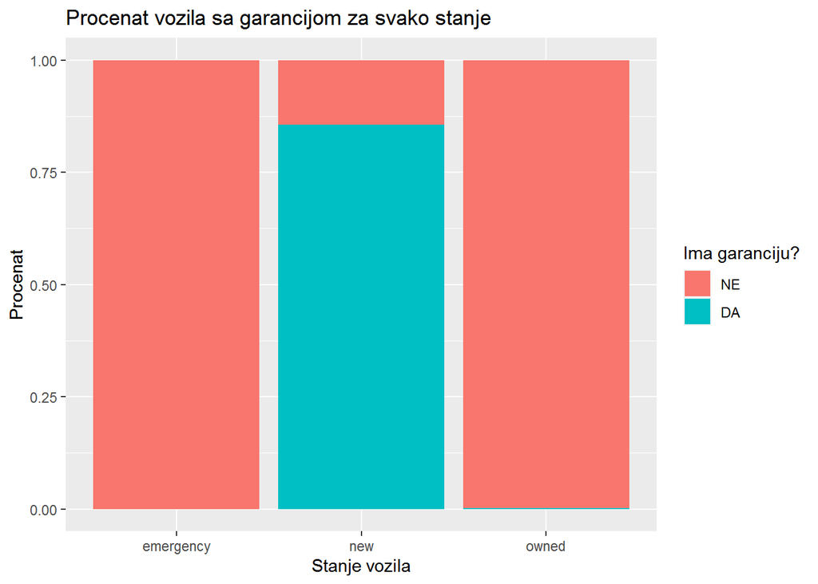

```r
 ggplot(carSubset, aes(state, fill=has_warranty )) + geom_bar(position = position_fill()) + labs(x = "Stanje vozila", y="Procenat", title="Procenat vozila sa garancijom za svako stanje") +scale_fill_discrete(name="Ima garanciju?", labels=c("NE", "DA"))
```

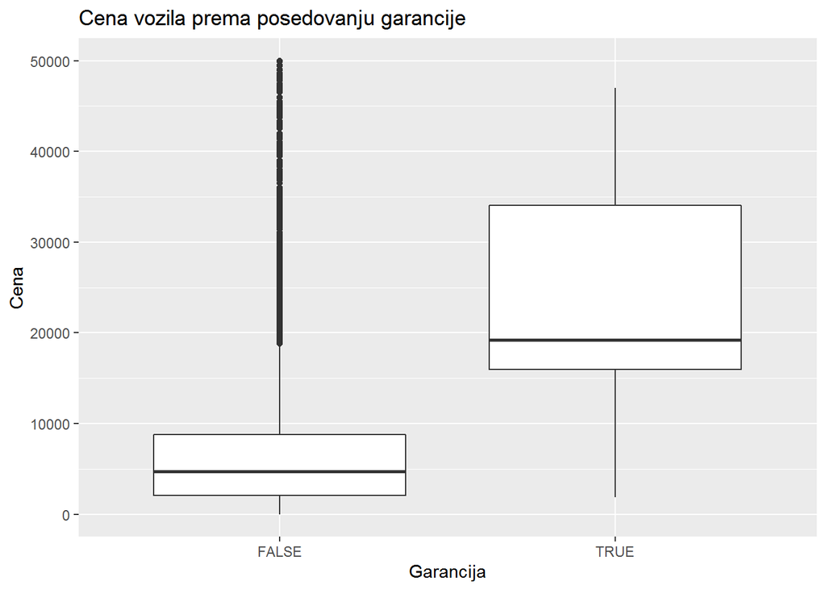

```r
ggplot(carSubset) + geom_boxplot(aes(x=has_warranty, y= price_usd)) + labs(x = "Garancija", y="Cena", title="Cena vozila prema posedovanju garancije")
```

Као што смо и раније могли да закључимо, возила са гаранцијом имају вишу цену из следећих разлога које смо приказали на претходним графицима. Тачније нова возила чешће имају гаранцију, самим тим имају и вишу цену.

Моделовање

Формулација тренинг и тест скупа

Скуп података ћемо поделити на тренинг и тест подскуп, у односу 80 према 20.

```r
set.seed(1)
size=floor(0.8*nrow(carSubset))
train_ind = sample(seq_len(nrow(carSubset)), size=size)

train = carSubset[train_ind,]
str(train)
```

```
## 'data.frame':    30768 obs. of  19 variables:
##  $ manufacturer_name: Factor w/ 55 levels "Acura","Alfa Romeo",..: 8 41 20 24 49 45 12 24 24 53 ...
##  $ transmission     : Factor w/ 2 levels "automatic","mechanical": 1 1 1 1 1 2 2 2 1 2 ...
##  $ color            : Factor w/ 12 levels "black","blue",..: 6 7 9 3 5 9 9 9 9 9 ...
##  $ odometer_value   : int  150000 435000 158000 132000 180000 406000 222222 340000 256000 271000 ...
##  $ year_produced    : int  2005 2000 2003 2014 2011 2003 2000 2002 2004 2006 ...
##  $ engine_fuel      : Factor w/ 6 levels "diesel","electric",..: 4 1 1 4 4 4 4 1 1 4 ...
##  $ engine_has_gas   : logi  FALSE FALSE FALSE FALSE FALSE FALSE ...
##  $ engine_type      : Factor w/ 3 levels "diesel","electric",..: 3 1 1 3 3 3 3 1 1 3 ...
##  $ engine_capacity  : num  2.2 2.5 1.6 2.4 1.4 2 1.5 2.2 2.5 1.8 ...
##  $ body_type        : Factor w/ 12 levels "cabriolet","coupe",..: 11 11 3 10 4 11 9 10 6 9 ...
##  $ has_warranty     : logi  FALSE FALSE FALSE FALSE FALSE FALSE ...
##  $ state            : Factor w/ 3 levels "emergency","new",..: 3 3 3 3 3 3 3 3 3 3 ...
##  $ drivetrain       : Factor w/ 3 levels "all","front",..: 2 3 2 1 2 2 2 2 3 2 ...
##  $ price_usd        : num  9450 3400 5500 21000 7000 ...
##  $ is_exchangeable  : logi  TRUE TRUE FALSE FALSE FALSE FALSE ...
##  $ number_of_photos : int  16 11 5 4 8 1 7 9 8 19 ...
##  $ duration_listed  : int  129 178 58 7 52 57 35 14 37 20 ...
##  $ price_cat        : Factor w/ 5 levels "extraLowPrice",..: 5 4 5 3 5 5 1 5 5 5 ...
##  $ year_produced_cat: Factor w/ 4 levels "medAgeCar","newCar",..: 1 3 1 2 1 1 3 1 1 1 ...
```

```r
test = carSubset[-train_ind,]
str(test)
```

```
## 'data.frame':    7692 obs. of  19 variables:
##  $ manufacturer_name: Factor w/ 55 levels "Acura","Alfa Romeo",..: 51 51 51 51 51 51 51 51 51 51 ...
##  $ transmission     : Factor w/ 2 levels "automatic","mechanical": 1 2 2 1 1 1 1 1 2 2 ...
##  $ color            : Factor w/ 12 levels "black","blue",..: 9 7 8 1 9 11 7 10 1 2 ...
##  $ odometer_value   : int  571317 280000 49999 163219 179000 257495 250000 377000 123456 296000 ...
##  $ year_produced    : int  1999 2003 2001 2004 2014 2008 2007 1999 1991 2003 ...
##  $ engine_fuel      : Factor w/ 6 levels "diesel","electric",..: 4 4 4 4 4 4 4 4 4 3 ...
##  $ engine_has_gas   : logi  FALSE FALSE FALSE FALSE FALSE FALSE ...
##  $ engine_type      : Factor w/ 3 levels "diesel","electric",..: 3 3 3 3 3 3 3 3 3 3 ...
##  $ engine_capacity  : num  2.5 2 1.3 2 2 2.5 3 2.5 2.2 2 ...
##  $ body_type        : Factor w/ 12 levels "cabriolet","coupe",..: 11 10 3 11 10 11 10 11 9 11 ...
##  $ has_warranty     : logi  FALSE FALSE FALSE FALSE FALSE FALSE ...
##  $ state            : Factor w/ 3 levels "emergency","new",..: 3 3 3 3 3 3 3 3 3 3 ...
##  $ drivetrain       : Factor w/ 3 levels "all","front",..: 1 1 1 1 1 1 1 1 1 1 ...
##  $ price_usd        : num  4200 6900 1666 7300 12700 ...
##  $ is_exchangeable  : logi  TRUE TRUE FALSE TRUE FALSE FALSE ...
##  $ number_of_photos : int  8 14 8 17 14 10 7 12 6 7 ...
##  $ duration_listed  : int  43 11 230 35 16 13 204 21 20 10 ...
##  $ price_cat        : Factor w/ 5 levels "extraLowPrice",..: 5 5 4 5 3 5 5 4 1 5 ...
##  $ year_produced_cat: Factor w/ 4 levels "medAgeCar","newCar",..: 3 1 1 1 2 1 1 3 3 1 ...
```

```r
corr = cor(carSubset[, sapply(carSubset,is.numeric)], use="complete.obs", method="pearson")

corr
```

```
##                  odometer_value year_produced engine_capacity   price_usd
## odometer_value      1.000000000  -0.513500707     0.106137642 -0.42313498
## year_produced      -0.513500707   1.000000000     0.006186629  0.71978456
## engine_capacity     0.106137642   0.006186629     1.000000000  0.29658969
## price_usd          -0.423134983   0.719784560     0.296589686  1.00000000
## number_of_photos   -0.144608171   0.262527652     0.106855795  0.31717494
## duration_listed     0.002341601  -0.009389753     0.081586556  0.03441156
##                  number_of_photos duration_listed
## odometer_value        -0.14460817     0.002341601
## year_produced          0.26252765    -0.009389753
## engine_capacity        0.10685580     0.081586556
## price_usd              0.31717494     0.034411555
## number_of_photos       1.00000000    -0.028491886
## duration_listed       -0.02849189     1.000000000
```

Помоћу функције cor представљена је табела корелације нумеричких променљивих из скупа података. Из ове табеле видимо да најбољи међусобни однос имају колоне price_usd и year_produced, што значи да цену најбоље одређује година производње возила.

Линеарна регресија

```r
lm1 = lm(price_usd ~ year_produced + I(year_produced^2)  , data=train)
summary(lm1)
```

```
##
## Call:
## lm(formula = price_usd ~ year_produced + I(year_produced^2),
##     data = train)
##
## Residuals:
##    Min     1Q Median     3Q    Max
## -16174  -1684   -447   1052  36264
##
## Coefficients:
##                      Estimate Std. Error t value Pr(>|t|)
## (Intercept)         8.919e+07  1.150e+06   77.58   <2e-16 ***
## year_produced      -8.968e+04  1.149e+03  -78.08   <2e-16 ***
## I(year_produced^2)  2.254e+01  2.868e-01   78.60   <2e-16 ***
## ---
## Signif. codes:  0 '***' 0.001 '**' 0.01 '*' 0.05 '.' 0.1 ' ' 1
##
## Residual standard error: 4064 on 30765 degrees of freedom
## Multiple R-squared:  0.5994, Adjusted R-squared:  0.5993
## F-statistic: 2.301e+04 on 2 and 30765 DF,  p-value: < 2.2e-16
```

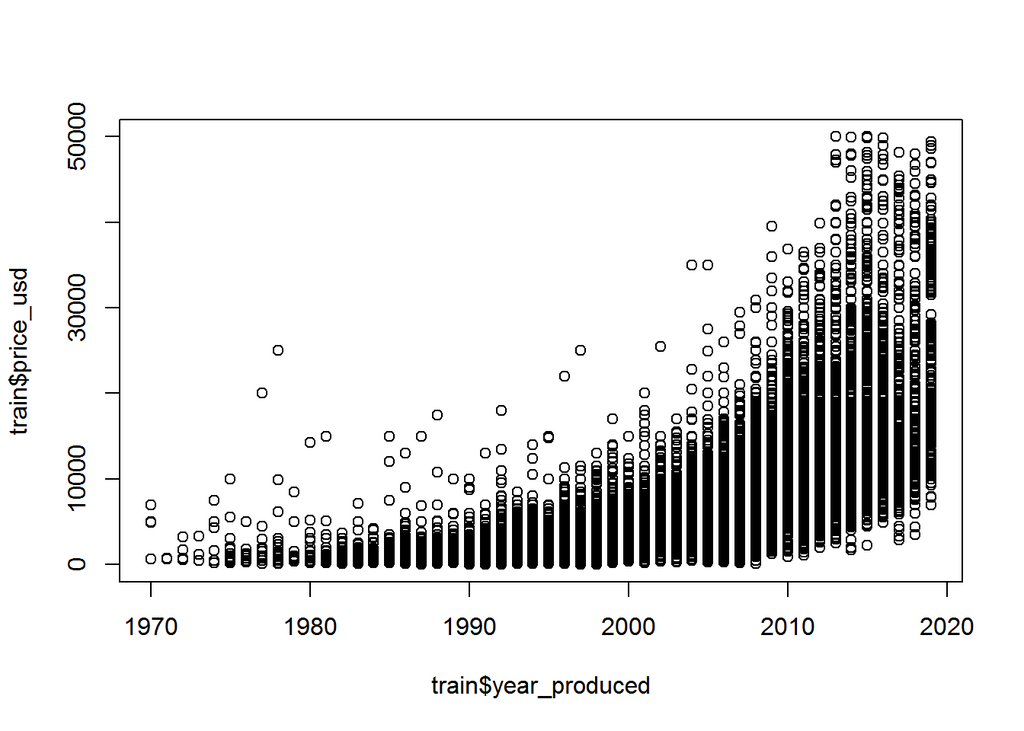

```r
plot(train$year_produced, train$price_usd)
abline(lm1, col="red")
```

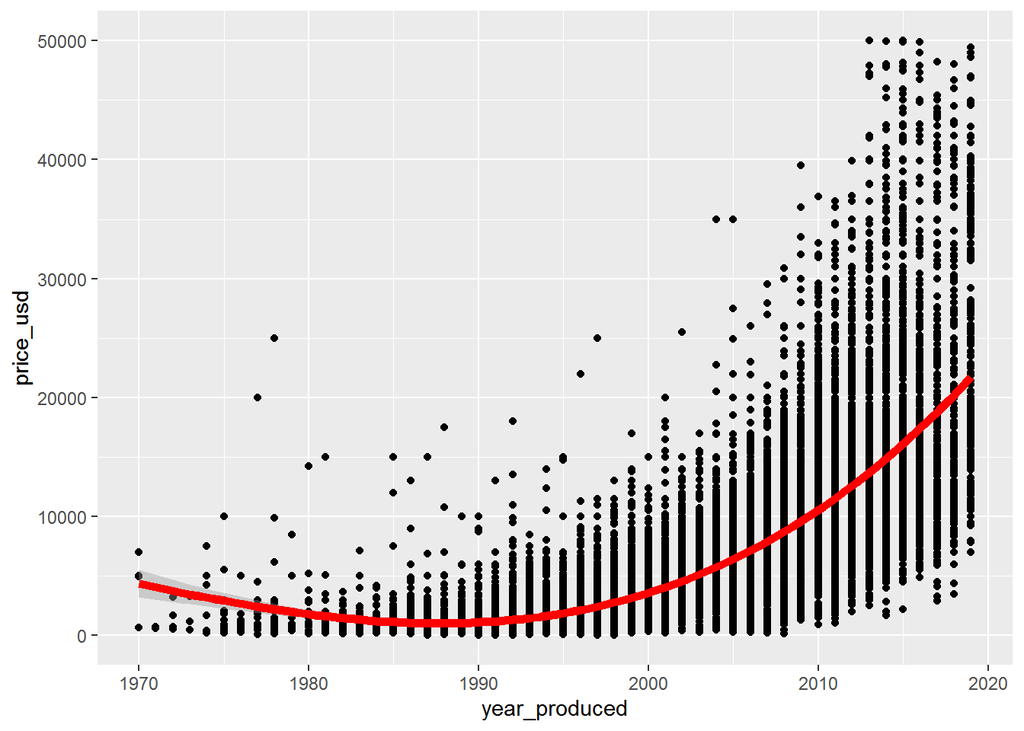

```r
ggplot(train,aes(x=year_produced, y=price_usd) ) + geom_point() + stat_smooth(method = lm, formula=y~poly(x,5, raw=TRUE), size=2,col="red")
```

```r
regFit = regsubsets(price_usd ~ odometer_value + year_produced + state +  engine_capacity + drivetrain + number_of_photos, data =train, nvmax=5, really.big = T)
summary(regFit)
```

```
## Subset selection object
## Call: regsubsets.formula(price_usd ~ odometer_value + year_produced +
##     state + engine_capacity + drivetrain + number_of_photos,
##     data = train, nvmax = 5, really.big = T)
## 8 Variables  (and intercept)
##                  Forced in Forced out
## odometer_value       FALSE      FALSE
## year_produced        FALSE      FALSE
## statenew             FALSE      FALSE
## stateowned           FALSE      FALSE
## engine_capacity      FALSE      FALSE
## drivetrainfront      FALSE      FALSE
## drivetrainrear       FALSE      FALSE
## number_of_photos     FALSE      FALSE
## 1 subsets of each size up to 5
## Selection Algorithm: exhaustive
##          odometer_value year_produced statenew stateowned engine_capacity
## 1  ( 1 ) " "            "*"           " "      " "        " "
## 2  ( 1 ) " "            "*"           " "      " "        " "
## 3  ( 1 ) " "            "*"           "*"      " "        " "
## 4  ( 1 ) " "            "*"           "*"      " "        "*"
## 5  ( 1 ) " "            "*"           "*"      " "        "*"
##          drivetrainfront drivetrainrear number_of_photos
## 1  ( 1 ) " "             " "            " "
## 2  ( 1 ) "*"             " "            " "
## 3  ( 1 ) "*"             " "            " "
## 4  ( 1 ) "*"             " "            " "
## 5  ( 1 ) "*"             " "            "*"
```

```r
lm2 = lm(price_usd ~ year_produced + I(year_produced^2) + I(year_produced^3) * drivetrain + state + engine_capacity + I(engine_capacity^2) + sqrt(number_of_photos), data = train)
summary(lm2)
```

```
##
## Call:
## lm(formula = price_usd ~ year_produced + I(year_produced^2) +
##     I(year_produced^3) * drivetrain + state + engine_capacity +
##     I(engine_capacity^2) + sqrt(number_of_photos), data = train)
##
## Residuals:
##      Min       1Q   Median       3Q      Max
## -18221.5  -1245.0    -97.1   1057.4  30783.5
##
## Coefficients:
##                                      Estimate Std. Error t value Pr(>|t|)
## (Intercept)                        -1.120e+09  1.462e+08  -7.658 1.94e-14 ***
## year_produced                       1.727e+06  2.193e+05   7.877 3.46e-15 ***
## I(year_produced^2)                 -8.882e+02  1.097e+02  -8.100 5.70e-16 ***
## I(year_produced^3)                  1.522e-01  1.828e-02   8.327  < 2e-16 ***
## drivetrainfront                     3.328e+05  5.255e+03  63.326  < 2e-16 ***
## drivetrainrear                      1.622e+05  6.475e+03  25.045  < 2e-16 ***
## statenew                            5.921e+03  2.505e+02  23.638  < 2e-16 ***
## stateowned                          1.930e+03  1.729e+02  11.164  < 2e-16 ***
## engine_capacity                     4.428e+03  1.097e+02  40.367  < 2e-16 ***
## I(engine_capacity^2)               -3.868e+02  1.851e+01 -20.902  < 2e-16 ***
## sqrt(number_of_photos)              3.916e+02  1.895e+01  20.664  < 2e-16 ***
## I(year_produced^3):drivetrainfront -4.159e-05  6.500e-07 -63.977  < 2e-16 ***
## I(year_produced^3):drivetrainrear  -2.015e-05  8.043e-07 -25.051  < 2e-16 ***
## ---
## Signif. codes:  0 '***' 0.001 '**' 0.01 '*' 0.05 '.' 0.1 ' ' 1
##
## Residual standard error: 2941 on 30755 degrees of freedom
## Multiple R-squared:  0.7903, Adjusted R-squared:  0.7902
## F-statistic:  9660 on 12 and 30755 DF,  p-value: < 2.2e-16
```

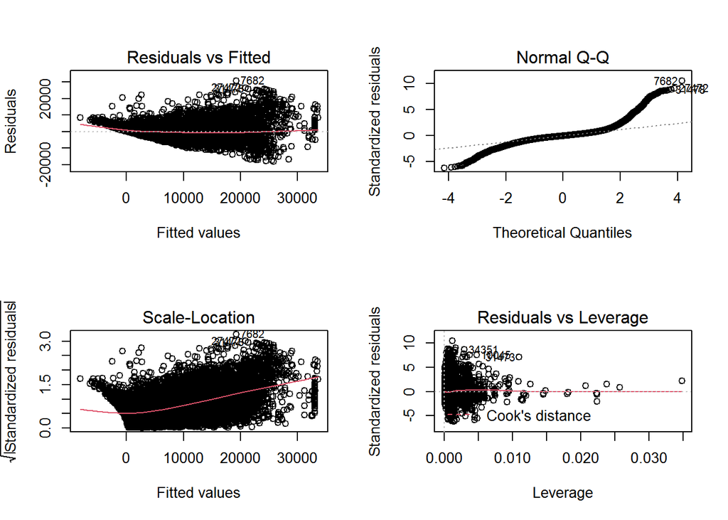

```r
par(mfrow=c(2, 2))
plot(lm2)
```

```r
lm3 = lm(log(price_usd) ~ year_produced + I(year_produced^2) + I(year_produced^3) * drivetrain + state + engine_capacity + I(engine_capacity^2) + sqrt(number_of_photos), data = train)

summary(lm3)
```

```
##
## Call:
## lm(formula = log(price_usd) ~ year_produced + I(year_produced^2) +
##     I(year_produced^3) * drivetrain + state + engine_capacity +
##     I(engine_capacity^2) + sqrt(number_of_photos), data = train)
##
## Residuals:
##     Min      1Q  Median      3Q     Max
## -7.0483 -0.2125  0.0288  0.2454  2.8636
##
## Coefficients:
##                                      Estimate Std. Error t value Pr(>|t|)
## (Intercept)                         8.777e+05  2.197e+04  39.951  < 2e-16 ***
## year_produced                      -1.315e+03  3.296e+01 -39.895  < 2e-16 ***
## I(year_produced^2)                  6.564e-01  1.648e-02  39.836  < 2e-16 ***
## I(year_produced^3)                 -1.092e-04  2.746e-06 -39.775  < 2e-16 ***
## drivetrainfront                    -4.621e+00  7.896e-01  -5.852 4.92e-09 ***
## drivetrainrear                     -4.703e+00  9.730e-01  -4.833 1.35e-06 ***
## statenew                            1.358e+00  3.764e-02  36.075  < 2e-16 ***
## stateowned                          1.032e+00  2.598e-02  39.710  < 2e-16 ***
## engine_capacity                     1.022e+00  1.649e-02  61.993  < 2e-16 ***
## I(engine_capacity^2)               -1.186e-01  2.781e-03 -42.636  < 2e-16 ***
## sqrt(number_of_photos)              6.586e-02  2.848e-03  23.129  < 2e-16 ***
## I(year_produced^3):drivetrainfront  5.496e-10  9.768e-11   5.626 1.86e-08 ***
## I(year_produced^3):drivetrainrear   5.815e-10  1.209e-10   4.811 1.51e-06 ***
## ---
## Signif. codes:  0 '***' 0.001 '**' 0.01 '*' 0.05 '.' 0.1 ' ' 1
##
## Residual standard error: 0.4419 on 30755 degrees of freedom
## Multiple R-squared:  0.8143, Adjusted R-squared:  0.8143
## F-statistic: 1.124e+04 on 12 and 30755 DF,  p-value: < 2.2e-16
```

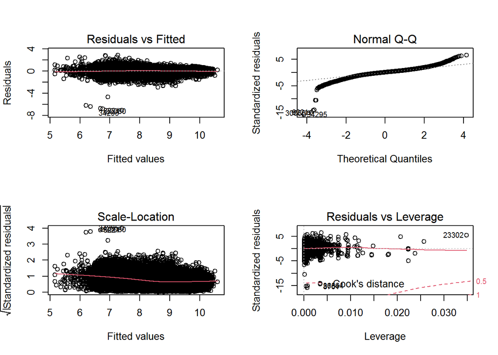

```r
pred1 = predict(lm3,test,interval="confidence")
par(mfrow=c(2, 2))
plot(lm3)
```

Scale-Location је показатељ добре хомогености варијансе резидуала јер запажамо да су подаци подједнако удаљени од хоризонталне линије.

Residuals vs Leverage je график на основу ког увиђамо да постоје „high-leverage“ вредности.

Из приложених података о линеарној регресији, закључује се да цене доста варирају. На пример, mean за цену је 6640, а модел греши за око 3000. Дакле, модел линеарне регресије, није најбоље решење за предикцију.

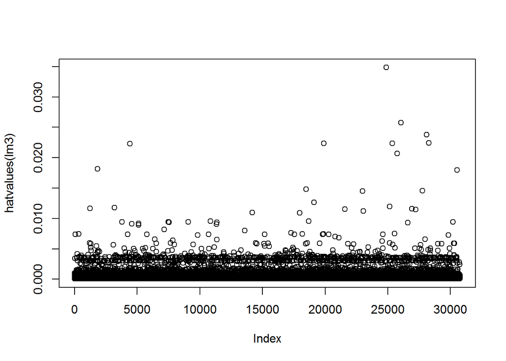

```r
plot(hatvalues(lm3))
```

```r
num1 <- which.max(hatvalues(lm3))

str(num1)
```

```
##  Named int 24868
##  - attr(*, "names")= chr "23302"
```

Стабло одлучивања модел машинског учења

```r
library(e1071)
library(rattle)
library(rpart)
library(caret)
```

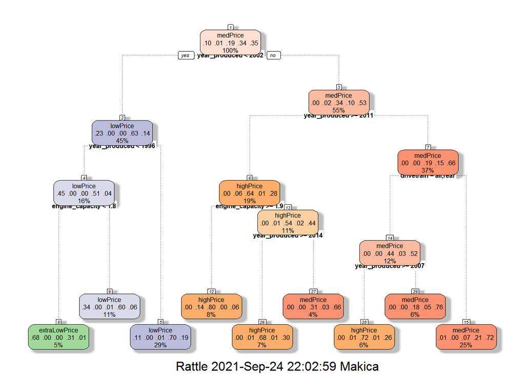

```r
library(rpart.plot)
tree_model = rpart(price_cat ~ .,data=subset(train, select=c( -price_usd,-manufacturer_name, - duration_listed ,-color, -number_of_photos) ),method = "class")


fancyRpartPlot(tree_model, cex=0.5)
```

```r
printcp(tree_model)
```

```
##
## Classification tree:
## rpart(formula = price_cat ~ ., data = subset(train, select = c(-price_usd,
##     -manufacturer_name, -duration_listed, -color, -number_of_photos)),
##     method = "class")
##
## Variables actually used in tree construction:
## [1] drivetrain      engine_capacity year_produced
##
## Root node error: 19853/30768 = 0.64525
##
## n= 30768
##
##         CP nsplit rel error  xerror      xstd
## 1 0.340956      0   1.00000 1.00000 0.0042272
## 2 0.103863      1   0.65904 0.65904 0.0043680
## 3 0.020123      2   0.55518 0.55518 0.0042364
## 4 0.014280      4   0.51493 0.51493 0.0041617
## 5 0.011736      6   0.48637 0.48637 0.0041000
## 6 0.010000      8   0.46290 0.46290 0.0040438
```

```r
tree_model$variable.importance
```

```
##     year_produced year_produced_cat    odometer_value      transmission
##        7200.33779        5154.33670        2646.02060        1192.77396
##        drivetrain   engine_capacity         body_type             state
##        1116.17065         824.54505         689.68750          87.20271
##      has_warranty       engine_fuel       engine_type
##          83.92967          30.35571          30.35571
```

```r
predTree <- predict(tree_model, test, type="class")


confMatrix <- table(predTree, test$has_warranty)
##fourfoldplot(confMatrix, color = c("#CC6666", "#99CC99"),
           ### conf.level = 0, margin = 1, main = "Confusion Matrix of Decision tree")
cnfPT2 <- table(predTree, test$price_cat, dnn=c("Prediction", "Actual"))

require(caret)
cnf1 <- confusionMatrix(predTree,test$price_cat)
plt <- as.data.frame(cnf1$table)

 confusionMatrix(predTree,test$price_cat)
```

```
## Confusion Matrix and Statistics
##
##                Reference
## Prediction      extraLowPrice extraPrice highPrice lowPrice medPrice
##   extraLowPrice           252          0         0      115        2
##   extraPrice                0          0         0        0        0
##   highPrice                 2         93      1103        7      324
##   lowPrice                530          0        14     2020      458
##   medPrice                 13          0       343      433     1983
##
## Overall Statistics
##
##                Accuracy : 0.6966
##                  95% CI : (0.6862, 0.7068)
##     No Information Rate : 0.3597
##     P-Value [Acc > NIR] : < 2.2e-16
##
##                   Kappa : 0.5641
##
##  Mcnemar's Test P-Value : NA
##
## Statistics by Class:
##
##                      Class: extraLowPrice Class: extraPrice Class: highPrice
## Sensitivity                       0.31619           0.00000           0.7555
## Specificity                       0.98303           1.00000           0.9316
## Pos Pred Value                    0.68293               NaN           0.7214
## Neg Pred Value                    0.92558           0.98791           0.9421
## Prevalence                        0.10361           0.01209           0.1898
## Detection Rate                    0.03276           0.00000           0.1434
## Detection Prevalence              0.04797           0.00000           0.1988
## Balanced Accuracy                 0.64961           0.50000           0.8436
##                      Class: lowPrice Class: medPrice
## Sensitivity                   0.7845          0.7167
## Specificity                   0.8042          0.8398
## Pos Pred Value                0.6684          0.7154
## Neg Pred Value                0.8812          0.8407
## Prevalence                    0.3348          0.3597
## Detection Rate                0.2626          0.2578
## Detection Prevalence          0.3929          0.3604
## Balanced Accuracy             0.7943          0.7782
```

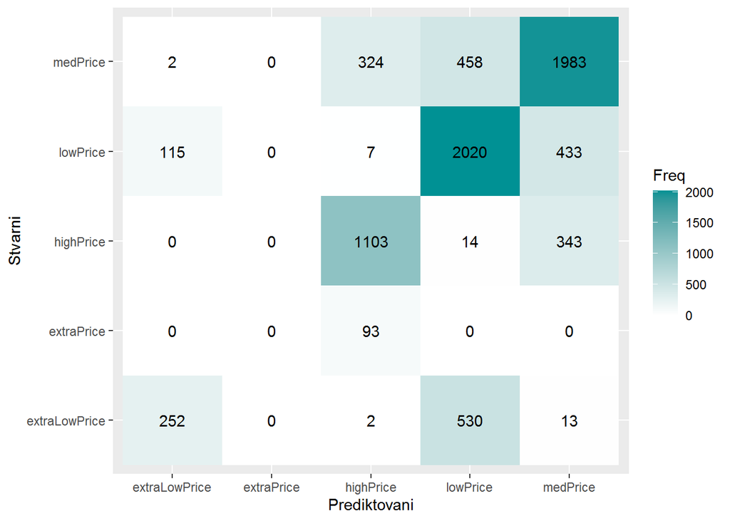

```r
ggplot(plt, aes(Prediction,Reference, fill= Freq)) +
        geom_tile() + geom_text(aes(label=Freq)) +
        scale_fill_gradient(low="white", high="#009194") +
        labs(x = "Prediktovani",y = "Stvarni") +
        scale_x_discrete(labels=c("extraLowPrice","extraPrice","highPrice","lowPrice","medPrice")) +
        scale_y_discrete(labels=c("extraLowPrice","extraPrice","highPrice","lowPrice","medPrice"))
```

```r
predAct = data.frame(cbind(actual=test$price_cat, predicted=predTree))
predAct[1:100,]
```

```
##     actual predicted
## 10       5         4
## 11       5         5
## 14       4         4
## 16       5         5
## 19       3         3
## 21       5         3
## 26       5         3
## 28       4         4
## 34       1         4
## 59       5         5
## 60       3         3
## 69       5         3
## 75       3         3
## 83       5         3
```

[output cut: 86 more lines]

Метрике

```r
(precision <- diag(cnfPT2) / sum(cnfPT2))
```

```
## extraLowPrice    extraPrice     highPrice      lowPrice      medPrice
##    0.03276131    0.00000000    0.14339574    0.26261050    0.25780031
```

Одзив

```r
(recall <- (diag(cnfPT2) / colSums(cnfPT2)))
```

```
## extraLowPrice    extraPrice     highPrice      lowPrice      medPrice
##     0.3161857     0.0000000     0.7554795     0.7844660     0.7166606
```

Ф1 Скор

```r
(F1 <- 2*precision*recall/(precision+recall))
```

```
## extraLowPrice    extraPrice     highPrice      lowPrice      medPrice
##    0.05937095           NaN    0.24104021    0.39349372    0.37919495
```

SUPPORT VECTOR MACHINE ALGORITAM MASINSKOG UCENJA

```r
svm1 <- svm(price_cat ~ ., data = subset(train, select = c(-price_usd,
    -manufacturer_name, -duration_listed, -color, -number_of_photos)), method = "C-classification", kernel ="radial",gamma= 0.1,cost =10)
```

```r
predSVM <- predict(svm1,test)

cnfSVM <- confusionMatrix(predSVM,test$price_cat)
plt <- as.data.frame(cnfSVM$table)
cnfSVM2 <- table(predSVM, test$price_cat, dnn=c("Prediction", "Actual"))

confusionMatrix(predSVM,test$price_cat)
```

```
## Confusion Matrix and Statistics
##
##                Reference
## Prediction      extraLowPrice extraPrice highPrice lowPrice medPrice
##   extraLowPrice           308          0         0      121        1
##   extraPrice                0         49        20        0        0
##   highPrice                 0         44      1199        2      232
##   lowPrice                483          0         7     2159      331
##   medPrice                  6          0       234      293     2203
##
## Overall Statistics
##
##                Accuracy : 0.7694
##                  95% CI : (0.7598, 0.7787)
##     No Information Rate : 0.3597
##     P-Value [Acc > NIR] : < 2.2e-16
##
##                   Kappa : 0.6705
##
##  Mcnemar's Test P-Value : NA
##
## Statistics by Class:
##
##                      Class: extraLowPrice Class: extraPrice Class: highPrice
## Sensitivity                       0.38645           0.52688           0.8212
## Specificity                       0.98231           0.99737           0.9554
## Pos Pred Value                    0.71628           0.71014           0.8118
## Neg Pred Value                    0.93266           0.99423           0.9580
## Prevalence                        0.10361           0.01209           0.1898
## Detection Rate                    0.04004           0.00637           0.1559
## Detection Prevalence              0.05590           0.00897           0.1920
## Balanced Accuracy                 0.68438           0.76212           0.8883
##                      Class: lowPrice Class: medPrice
## Sensitivity                   0.8384          0.7962
## Specificity                   0.8396          0.8918
## Pos Pred Value                0.7245          0.8052
## Neg Pred Value                0.9117          0.8862
## Prevalence                    0.3348          0.3597
## Detection Rate                0.2807          0.2864
## Detection Prevalence          0.3874          0.3557
## Balanced Accuracy             0.8390          0.8440
```

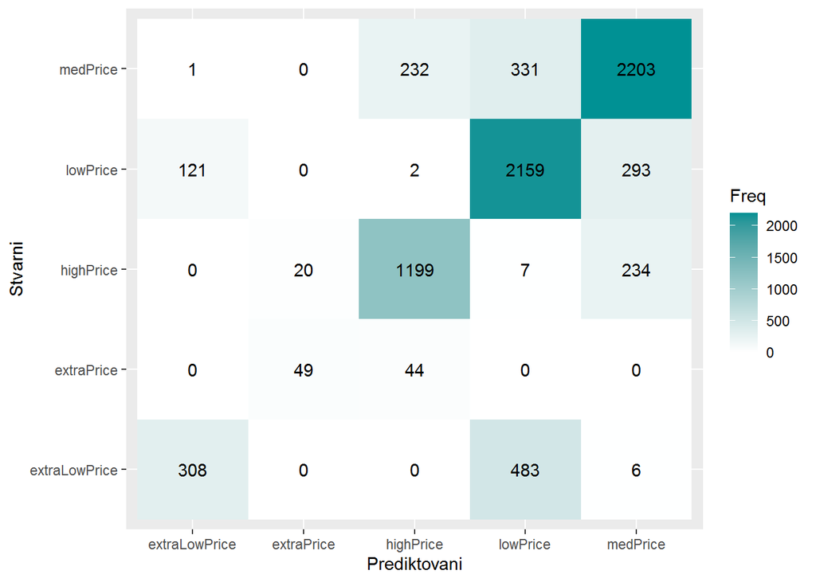

```r
ggplot(plt, aes(Prediction,Reference, fill= Freq)) +
        geom_tile() + geom_text(aes(label=Freq)) +
        scale_fill_gradient(low="white", high="#009194") +
        labs(x = "Prediktovani",y = "Stvarni") +
        scale_x_discrete(labels=c("extraLowPrice","extraPrice","highPrice","lowPrice","medPrice")) +
        scale_y_discrete(labels=c("extraLowPrice","extraPrice","highPrice","lowPrice","medPrice"))
```

```r
predAct1 = data.frame(cbind(actual=test$price_cat, predicted=predSVM))
predAct1[1:100,]
```

```
##     actual predicted
## 10       5         4
## 11       5         5
## 14       4         4
## 16       5         5
## 19       3         3
## 21       5         5
## 26       5         3
## 28       4         4
## 34       1         4
## 59       5         5
## 60       3         3
## 69       5         3
## 75       3         3
## 83       5         3
```

[output cut: 86 more lines]

Метрике

```r
(precision <- diag(cnfSVM2) / sum(cnfSVM2))
```

```
## extraLowPrice    extraPrice     highPrice      lowPrice      medPrice
##   0.040041602   0.006370255   0.155876235   0.280681227   0.286401456
```

Одзив

```r
(recall <- (diag(cnfSVM2) / colSums(cnfSVM2)))
```

```
## extraLowPrice    extraPrice     highPrice      lowPrice      medPrice
##     0.3864492     0.5268817     0.8212329     0.8384466     0.7961691
```

Ф1 Скор

```r
(F1 <- 2*precision*recall/(precision+recall))
```

```
## extraLowPrice    extraPrice     highPrice      lowPrice      medPrice
##    0.07256450    0.01258831    0.26201923    0.42057076    0.42126398
```

На основу статистичких вредности закључујемо да алгоритам SVM даје боље резултате. Тако да ће он бити изабран за предиктовање цене аутомобила.